# loon.ggplot

Zehao Xu

2018-09-13

## Introduction

`loon.ggplot` is a R package to transform `ggplot` graphics into interactive `loon` graphics.

## 1. Basic usage

```r
library(loon.ggplot)
g_scatter <- ggplot(mtcars, aes(wt, mpg)) + geom_point()
```

*loon plot*

`loon` provides `loonGrob` to transform `loon` graphics to `grid` `grob`s, then to capture the static display.

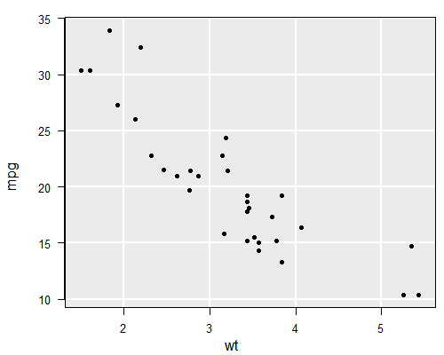

basic show loonplot

```r
lp_scatter <- loon.ggplot(g_scatter)
grid.newpage()
grid.loon(lp_scatter)
```

The points can be selected in `loon` plot

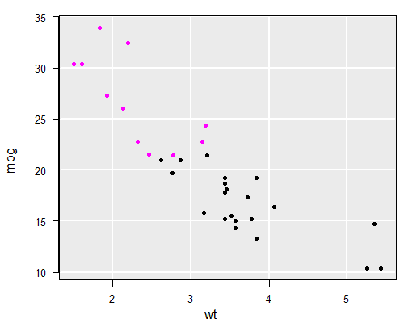

selected loonplot

```r
cyl4 <- which((mtcars$cyl == 4) == TRUE)
lp_scatter$plots$x1y1['selected'][cyl4] <- TRUE
grid.loon(lp_scatter)
```

Also, more interesting actions can be achieved, like changing color, size, glyph types and etc. In this vignette, we just use ‘selected’ to highlight and show difference. Please take a look at [`loon` display](http://waddella.github.io/loon/learn_R_display_plot.html) for more details (Notice, the output of `loon.ggplot` is a list and each element is the corresponding `loon` plot).

### 1.1.Coordinates and `ggGuides`

Let us look at the following example

```r
library(ElemStatLearn)
g_polar <- ggplot(SAheart, aes(obesity, adiposity)) + geom_point() + geom_smooth() +
  coord_polar(theta = "y")
```

The graphics are projected on the polar coordinates system with respect to “adiposity” (It is a pretty weird plot but does demonstrate how coordinate systems are abstracted out as part of the grammar.)

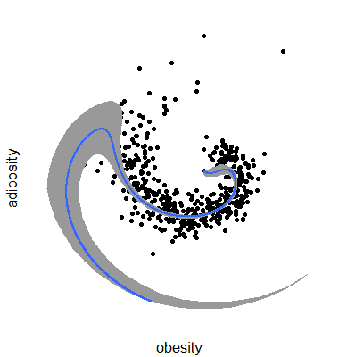

loonplot with polar coordinates

```r
lp_polar <- loon.ggplot(g_polar)
grid.loon(lp_polar)
```

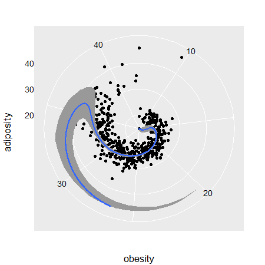

loonplot with ggGuides

```r
lp_polar_ggGuides <- loon.ggplot(g_polar, ggGuides = TRUE)
grid.loon(lp_polar_ggGuides)
```

`ggGuides` will return a `ggplot` object coordinates system (polar or Cartesian). It is extremely helpful under polar coordinates system, since this system is very difficult to interpret without any guiding.

### 1.2.Which one is active?

```r
g_hist_point <- ggplot(mtcars, aes(x = mpg, y = ..density..)) +
  geom_histogram() +
  geom_point(data = data.frame(x = mtcars$mpg, y = 0),
             mapping = aes(x, y),
            color = "steelblue", size = 3) +
  geom_density()
```

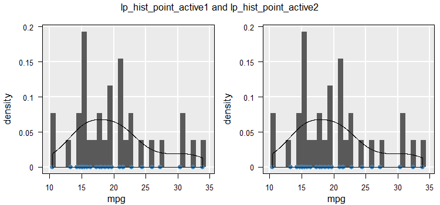

loonplot but with different active layers

```r
library(gridExtra)
## check difference
lp_hist_point_active1 <- loon.ggplot(g_hist_point, activeGeomLayers = 1)

suppressWarnings(
  lp_hist_point_active2 <- loon.ggplot(g_hist_point, activeGeomLayers = 2)
)

grid.arrange(loonGrob(lp_hist_point_active1), loonGrob(lp_hist_point_active2), ncol = 2, top = "lp_hist_point_active1 and lp_hist_point_active2")
```

Let us select the data larger than 20.

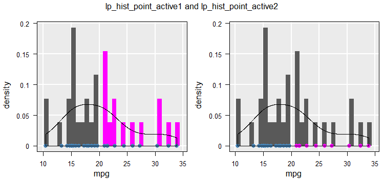

selected loonplot with different active layers

```r
lp_hist_point_active1$plots$x1y1['selected'][mtcars$mpg > 20] <- TRUE
lp_hist_point_active2$plots$x1y1['selected'][mtcars$mpg > 20] <- TRUE
grid.arrange(loonGrob(lp_hist_point_active1), loonGrob(lp_hist_point_active2), ncol = 2, top = "lp_hist_point_active1 and lp_hist_point_active2")
```

```r
# Error
loon.ggplot(g_hist_point, activeGeomLayers = 3)
# Error in activeInfo(importantLayers, activeGeomLayers, len_layers) : This layer cannot be active
loon.ggplot(g_hist_point, activeGeomLayers = c(1,2))
# Error in activeInfo(importantLayers, activeGeomLayers, len_layers) : histogram layer and point layer cannot be active at the same time
```

`loon.ggplot` also provides a function called `activeGeomLayers` to return the index of layers which can be active

```r
activeGeomLayers(g_hist_point)
```

[output not shown]

What if we have multiple point layers?

```r
df <- data.frame(
  x = rnorm(120, c(0, 2, 4)),
  y = rnorm(120, c(1, 2, 1)),
  z = letters[1:3]
)
df2 <- dplyr::select(df, -z)
g_three_scatterplots <- ggplot(df, aes(x, y)) +
  geom_point(data = df2, colour = "grey70") +
  geom_point(aes(colour = z)) +
  facet_wrap(~z)
```

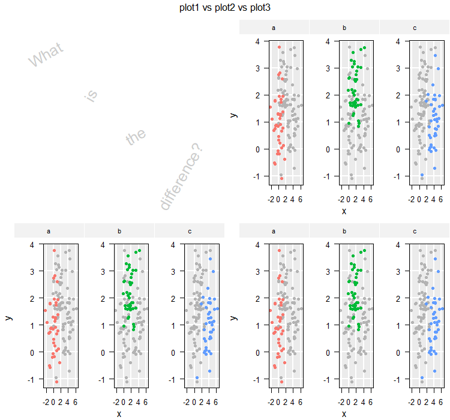

loonplot with several point layers layout

```r
suppressWarnings(
  lp_three_scatterplots_active1 <- loon.ggplot(g_three_scatterplots, activeGeomLayers = 1)
)
lp_three_scatterplots_active2 <- loon.ggplot(g_three_scatterplots, activeGeomLayers = 2)

suppressWarnings(
  lp_three_scatterplots_active12 <- loon.ggplot(g_three_scatterplots, activeGeomLayers = c(1,2))
)
grid.arrange(
  textGrob(
    c("What","is", "the" ,"difference?"),
    x = c(0.2, 0.4, 0.6, 0.8),
    y = c(0.8, 0.6, 0.4, 0.2),
    gp = gpar(col = "grey80", fontsize = 18),
    rot = c(30, 60, 30, 60)
  ),
  loonGrob(lp_three_scatterplots_active1),
  loonGrob(lp_three_scatterplots_active2),
  loonGrob(lp_three_scatterplots_active12),
  ncol = 2,
  nrow = 2,
  top = "plot1 vs plot2 vs plot3")
```

`lp_three_scatterplots_active2` has more statistical meanings than the other two. Let us select the points in three facets

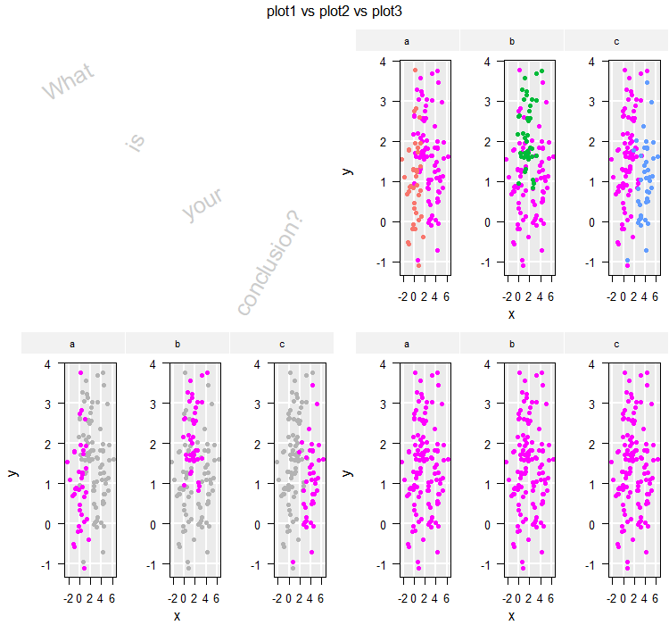

selected loonplot with several point layers layout

```r
# lp_three_scatterplots_active1
sel_lp_three_scatterplots_active1 <- lapply(lp_three_scatterplots_active1,
                      function(loon_plot){
                        loon_plot['selected'] <- TRUE
                      })
# lp_three_scatterplots_active2
sel_lp_three_scatterplots_active2 <- lapply(lp_three_scatterplots_active2,
                      function(loon_plot){
                        loon_plot['selected'] <- TRUE
                      })
# lp_three_scatterplots_active12
sel_lp_three_scatterplots_active12 <- lapply(lp_three_scatterplots_active12,
                      function(loon_plot){
                        loon_plot['selected'] <- TRUE
                      })
grid.arrange(
  textGrob(
    c("What","is", "your" ,"conclusion?"),
    x = c(0.2, 0.4, 0.6, 0.8),
    y = c(0.8, 0.6, 0.4, 0.2),
    gp = gpar(col = "grey80", fontsize = 18),
    rot = c(30, 60, 30, 60)
  ),
  loonGrob(lp_three_scatterplots_active1),
  loonGrob(lp_three_scatterplots_active2),
  loonGrob(lp_three_scatterplots_active12),
  ncol = 2,
  nrow = 2,
  top = "plot1 vs plot2 vs plot3")
```

In this example, the active points should be the colorful ones; the grey points are background and should **not** be activated. In `ggplot` object, the first layer is the grey point layer, thus we need to set `activeGeomLayers` as **2**. That is why `lp_three_scatterplots_active2` is more appropriate than the rest (no warnings).

Also, you can reset the `ggplot` model as

```r
g_three_scatterplots <- ggplot(df, aes(x, y)) +
  geom_point(aes(colour = z)) +
  geom_point(data = df2, colour = "grey70") +
  facet_wrap(~z)
```

Then, `lp_three_scatterplots_active1` would be the appropriate one.

### 1.3.`linkingGroup` and `linkingKey`

`loon` has a powerful interactive system, `linkingKey` and `linkingGroup`, so that some of their $n$ dimensional states can be synchronized. Displays are linked if their share the same `linkingGroup`; the $n$ dimensional `linkingKey` state controls which elements get synchronized between the linked displays. More details are shown in [`loon` linking](http://waddella.github.io/loon/learn_R_linking.html).

```r
g_linking_scatter <- ggplot(mtcars, aes(mpg, wt, colour = as.factor(cyl))) + geom_point()
g_linking_hist <- ggplot(mtcars, aes(x = mpg, fill = as.factor(cyl))) + geom_histogram()
```

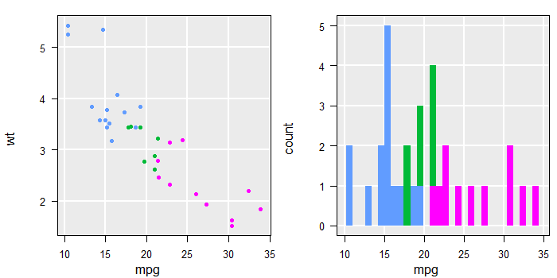

selected loonplot with linkingGroup and linkingKey

```r
lp_linking_scatter <- loon.ggplot(g_linking_scatter, linkingGroup = "mtcars")
lp_linking_hist <- loon.ggplot(g_linking_hist, linkingGroup = "mtcars")
lp_linking_scatter$plots$x1y1['selected'][which((mtcars$cyl == 4) == TRUE)] <- TRUE
# or
# lp_linking_hist$plots$x1y1['selected'][which((mtcars$cyl == 4) == TRUE)] <- TRUE
grid.arrange(loonGrob(lp_linking_scatter), loonGrob(lp_linking_hist), ncol = 2)
```

### 1.4.Handle `geom_curve`

```r
df <- data.frame(x = 1:3, y = 1:3)
df2 <- data.frame(x = c(1,3), y = c(1,3),
                  xend = c(2,2), yend = c(2,2))
g_curve <- ggplot(df, aes(x, y)) +
  geom_point() +
  geom_curve(aes(x = x ,y = y,
                 xend = xend, yend = yend),
             data = df2,
             color = c("red", "blue"))
loon.ggplot(g_curve)
```

Most geom layers in `ggplot` object are straight forward except `geom_curve`. Control points of `geom_curve` are from `curve grob` in `grid` and these points can only be achieved at the drawing time. Thus, “askYesorNo” option is generated, if `ggplot` graphics are drawn, curves would be shown in `loon` (or curves are replaced by segments).

## 2.Pipe ggplot model via `gg_pipe`

One convenient programming style is that of pipes as developed in the package `magrittr`.

```r
library(magrittr)
library(tidyverse)
SAheart %>%
  mutate(ltob = log(tobacco), lsbp = log(sbp)) %>%
  filter(age < 50) %>%
  ggplot(aes(x = ltob, y = lsbp)) +
  geom_point() +
  facet_wrap(~chd) -> gg
# the plot will be drawn at the end
lp_pipe <- loon.ggplot(gg)
```

However, if we pipe `ggplot` as following, error will occur

```r
## Error occures
SAheart %>%
  mutate(ltob = log(tobacco), lsbp = log(sbp)) %>%
  filter(age < 50) %>%
  ggplot(aes(x = ltob, y = lsbp)) +
  geom_point() +
  facet_wrap(~chd) %>%
  loon.ggplot()
```

The reason is the precedence of signal “+” and “%>%”. “%>%” takes the priority, thus

```
   facet_wrap(~chd) %>% loon.ggplot()
```

would run in front of

```
   ggplot(aes(x = ltob, y = lsbp)) +
     geom_point() +
     facet_wrap(~chd).
```

In `loon.ggplot`, `gg_pipe` packs the `ggplot` object and forces it to pass through in order.

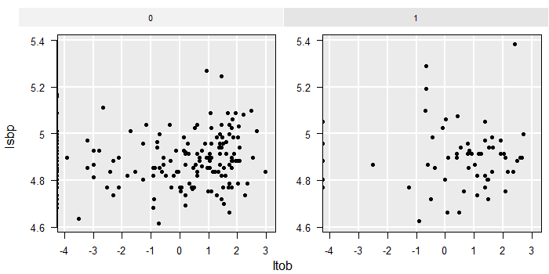

ggpipe

```r
## Works
SAheart %>%
  mutate(ltob = log(tobacco), lsbp = log(sbp)) %>%
  filter(age < 50) %>%
  gg_pipe(
    ggplot(aes(x = ltob, y = lsbp)) +
      geom_point() +
      facet_wrap(~chd)
  ) %>%
  loon.ggplot() %>%
  grid.loon()
```